# Assignment_5_Hierarchical Clustering

Chaitanya

2024-04-07

#Hierarchical clustering is a type of clustering algorithm that creates a hierarchy of clusters. It starts by treating each data point as its own cluster and then successively merges or splits clusters based on a specified distance metric until all data points belong to a single cluster.two main types of hierarchical clustering:1)Agglomerative (bottom-up) clustering has Different linkage methods (such as single linkage, complete linkage, average linkage, and Ward’s method)& 2) Divisive (top-down) clustering:

```r
# Load necessary libraries
library(cluster)
library(caret)
library(dendextend)
library(knitr)
library(factoextra)
library(knitr)
library(readr)
```

```r
# Read the dataset
Cereals_data <- read.csv("C:\\Users\\Chaitu\\Documents\\Cereals.csv")
Numerical_data <- data.frame(Cereals_data[,4:16])
```

```r
# Remove cereals with missing values
Numerical_data <- na.omit(Numerical_data)
```

```r
#Normalizing data
norm_cereals<- scale(Numerical_data)
```

```r
#By Using the normalized data to do hierarchical clustering using the Euclidean Dist technique.
EuclideanDist <- dist(norm_cereals, method = "euclidean")
Hierarchial_clust <- hclust(EuclideanDist, method = "complete")
```

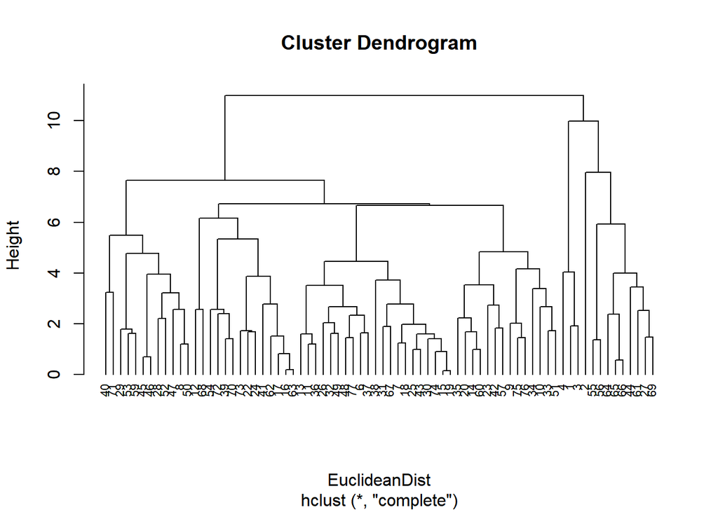

```r
# Hierarchical clustering produces a dendrogram, which is a tree-like diagram that illustrates the arrangement of the clusters.
plot(Hierarchial_clust, cex = 0.7, hang = -1)
```

```r
# Apply hierarchical clustering using different methods
single_Hierarchial_clust <- agnes(norm_cereals, method = "single")
complete_Hierarchial_clust <- agnes(norm_cereals, method = "complete")
average_Hierarchial_clust <- agnes(norm_cereals, method = "average")
ward_Hierarchial_clust <- agnes(norm_cereals, method = "ward")
```

```r
# Here printing the Agglomerative (bottom-up) clustering:
cat("Single Hierarchial_clust:", single_Hierarchial_clust$ac, "\n")
```

```
## Single Hierarchial_clust: 0.6067859
```

```r
cat("Complete Hierarchial_clust:", complete_Hierarchial_clust$ac, "\n")
```

```
## Complete Hierarchial_clust: 0.8353712
```

```r
cat("Average Hierarchial_clust:", average_Hierarchial_clust$ac, "\n")
```

```
## Average Hierarchial_clust: 0.7766075
```

```r
cat("Ward's Method:", ward_Hierarchial_clust$ac, "\n")
```

```
## Ward's Method: 0.9046042
```

# From the above hierarchial clustering the ward’s method is highest, because the value is 0.9046042 comparing to others.

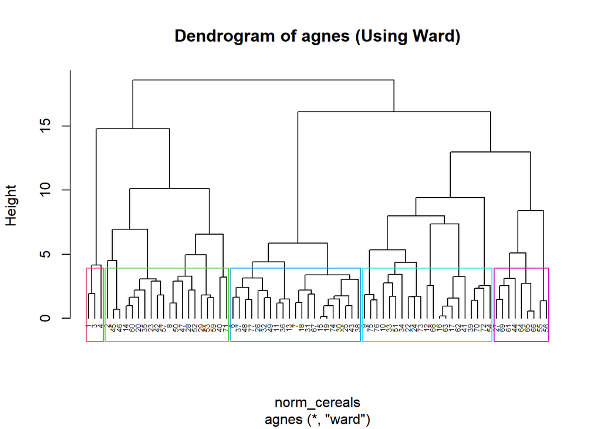

```r
#2. Choosing the clusters
pltree(ward_Hierarchial_clust, cex = 0.5, hang = -1, main = "Dendrogram of agnes (Using Ward)")
rect.hclust(ward_Hierarchial_clust, k = 5, border = 2:7)
```

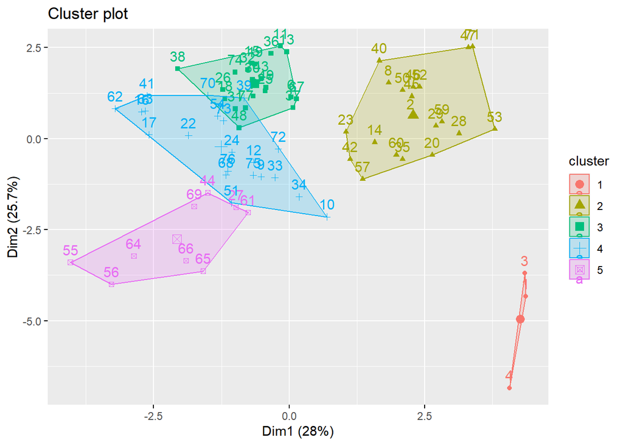

```r
Struc_Group <- cutree(ward_Hierarchial_clust, k=5)
Dataframe_2 <- as.data.frame(cbind(norm_cereals,Struc_Group))
fviz_cluster(list(data = Dataframe_2, cluster = Struc_Group))
```

#From the Cluster plot observation mentioned above, clusters can be selected. #determining the stability and structure ofthe clusters.

```r
#Building Partitions
set.seed(123)
First_partition <- Numerical_data[1:50,]
Second_partition <- Numerical_data[51:74,]
```

```r
#Performing Hierarchical Clustering while considering k = 5.
single_stability <- agnes(scale(First_partition), method = "single")
complete_stability <- agnes(scale(First_partition), method = "complete")
average_stability <- agnes(scale(First_partition), method = "average")
ward_stability <- agnes(scale(First_partition), method = "ward")
cbind(single=single_stability$ac , complete=complete_stability$ac , average= average_stability$ac , ward= ward_stability$ac)
```

```
##         single  complete   average      ward
## [1,] 0.6393338 0.8138238 0.7408904 0.8764323
```

#Plotting for ward’s method for Dendogram of Agnes with Partitioned Data.

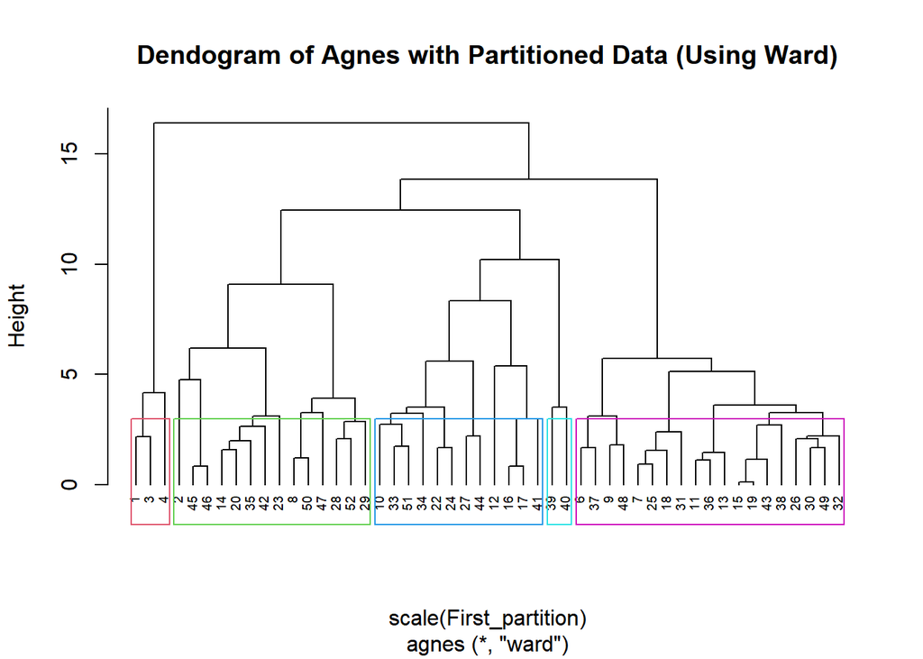

```r
pltree(ward_stability, cex = 0.6, hang = -1, main = "Dendogram of Agnes with Partitioned Data (Using Ward)")
rect.hclust(ward_stability, k = 5, border = 2:7)
```

```r
clust_2 <- cutree(ward_stability, k = 5)

#the centroids are calculated.
Stability_result <- as.data.frame(cbind(First_partition, clust_2))
Stability_result[Stability_result$clust_2==1,]
```

```
##   calories protein fat sodium fiber carbo sugars potass vitamins shelf weight
## 1       70       4   1    130    10     5      6    280       25     3      1
## 3       70       4   1    260     9     7      5    320       25     3      1
## 4       50       4   0    140    14     8      0    330       25     3      1
##   cups   rating clust_2
## 1 0.33 68.40297       1
## 3 0.33 59.42551       1
## 4 0.50 93.70491       1
```

#For first centroid

```r
First_centroid <- colMeans(Stability_result[Stability_result$clust_2==1,])
Stability_result[Stability_result$clust_2==2,]
```

```
##    calories protein fat sodium fiber carbo sugars potass vitamins shelf weight
## 2       120       3   5     15   2.0   8.0      8    135        0     3   1.00
## 8       130       3   2    210   2.0  18.0      8    100       25     3   1.33
## 14      110       3   2    140   2.0  13.0      7    105       25     3   1.00
## 20      110       3   3    140   4.0  10.0      7    160       25     3   1.00
## 23      100       2   1    140   2.0  11.0     10    120       25     3   1.00
## 28      120       3   2    160   5.0  12.0     10    200       25     3   1.25
## 29      120       3   0    240   5.0  14.0     12    190       25     3   1.33
## 35      120       3   3     75   3.0  13.0      4    100       25     3   1.00
## 42      100       4   2    150   2.0  12.0      6     95       25     2   1.00
## 45      150       4   3     95   3.0  16.0     11    170       25     3   1.00
## 46      150       4   3    150   3.0  16.0     11    170       25     3   1.00
## 47      160       3   2    150   3.0  17.0     13    160       25     3   1.50
## 50      140       3   2    220   3.0  21.0      7    130       25     3   1.33
## 52      130       3   2    170   1.5  13.5     10    120       25     3   1.25
##    cups   rating clust_2
## 2  1.00 33.98368       2
## 8  0.75 37.03856       2
## 14 0.50 40.40021       2
## 20 0.50 40.44877       2
## 23 0.75 36.17620       2
## 28 0.67 40.91705       2
## 29 0.67 41.01549       2
## 35 0.33 45.81172       2
## 42 0.67 45.32807       2
## 45 1.00 37.13686       2
## 46 1.00 34.13976       2
## 47 0.67 30.31335       2
## 50 0.67 40.69232       2
## 52 0.50 30.45084       2
```

#Printing the Second centroid

```r
Second_centroid <- colMeans(Stability_result[Stability_result$clust_2==2,])
Stability_result[Stability_result$clust_2==3,]
```

```
##    calories protein fat sodium fiber carbo sugars potass vitamins shelf weight
## 6       110       2   2    180   1.5  10.5     10     70       25     1      1
## 7       110       2   0    125   1.0  11.0     14     30       25     2      1
## 9        90       2   1    200   4.0  15.0      6    125       25     1      1
## 11      120       1   2    220   0.0  12.0     12     35       25     2      1
## 13      120       1   3    210   0.0  13.0      9     45       25     2      1
## 15      110       1   1    180   0.0  12.0     13     55       25     2      1
## 18      110       1   0     90   1.0  13.0     12     20       25     2      1
## 19      110       1   1    180   0.0  12.0     13     65       25     2      1
## 25      110       2   1    125   1.0  11.0     13     30       25     2      1
## 26      110       1   0    200   1.0  14.0     11     25       25     1      1
## 30      110       1   1    135   0.0  13.0     12     25       25     2      1
## 31      100       2   0     45   0.0  11.0     15     40       25     1      1
## 32      110       1   1    280   0.0  15.0      9     45       25     2      1
## 36      120       1   2    220   1.0  12.0     11     45       25     2      1
```

[output cut: 25 more lines]

#Printing the third_centroid

```r
third_centroid <- colMeans(Stability_result[Stability_result$clust_2==3,])
Stability_result[Stability_result$clust_2==4,]
```

```
##    calories protein fat sodium fiber carbo sugars potass vitamins shelf weight
## 10       90       3   0    210     5    13      5    190       25     3      1
## 12      110       6   2    290     2    17      1    105       25     1      1
## 16      110       2   0    280     0    22      3     25       25     1      1
## 17      100       2   0    290     1    21      2     35       25     1      1
## 22      110       2   0    220     1    21      3     30       25     3      1
## 24      100       2   0    190     1    18      5     80       25     3      1
## 27      100       3   0      0     3    14      7    100       25     2      1
## 33      100       3   1    140     3    15      5     85       25     3      1
## 34      110       3   0    170     3    17      3     90       25     3      1
## 41      110       2   1    260     0    21      3     40       25     2      1
## 44      100       4   1      0     0    16      3     95       25     2      1
## 51       90       3   0    170     3    18      2     90       25     3      1
##    cups   rating clust_2
## 10 0.67 53.31381       4
## 12 1.25 50.76500       4
## 16 1.00 41.44502       4
## 17 1.00 45.86332       4
## 22 1.00 46.89564       4
## 24 0.75 44.33086       4
## 27 0.80 58.34514       4
## 33 0.88 52.07690       4
## 34 0.25 53.37101       4
## 41 1.50 39.24111       4
## 44 1.00 54.85092       4
## 51 1.00 59.64284       4
```

#Printing the fourth_centroid

```r
fourth_centroid <- colMeans(Stability_result[Stability_result$clust_2==4,])
centroids <- rbind(First_centroid, Second_centroid, third_centroid, fourth_centroid)
x2 <- as.data.frame(rbind(centroids[,-14], Second_partition))
```

```r
#figuring out the Distance
Distance_1 <- get_dist(x2)
Matrix_1 <- as.matrix(Distance_1)
dataframe1 <- data.frame(data=seq(1,nrow(Second_partition),1), Clusters = rep(0,nrow(Second_partition)))
for(i in 1:nrow(Second_partition))
{dataframe1[i,2] <- which.min(Matrix_1[i+4, 1:4])}
dataframe1
```

```
##    data Clusters
## 1     1        1
## 2     2        4
## 3     3        3
## 4     4        2
## 5     5        2
## 6     6        1
## 7     7        2
## 8     8        2
## 9     9        3
## 10   10        3
## 11   11        2
## 12   12        2
## 13   13        2
## 14   14        3
## 15   15        4
## 16   16        2
## 17   17        3
## 18   18        2
## 19   19        4
## 20   20        4
## 21   21        3
## 22   22        4
## 23   23        4
## 24   24        3
```

```r
cbind(Dataframe_2$Struc_Group[51:74], dataframe1$Clusters)
```

```
##       [,1] [,2]
##  [1,]    2    1
##  [2,]    4    4
##  [3,]    5    3
##  [4,]    5    2
##  [5,]    2    2
##  [6,]    2    1
##  [7,]    2    2
##  [8,]    5    2
##  [9,]    4    3
## [10,]    4    3
## [11,]    5    2
## [12,]    5    2
## [13,]    5    2
## [14,]    3    3
## [15,]    4    4
## [16,]    5    2
## [17,]    4    3
## [18,]    2    2
## [19,]    4    4
## [20,]    4    4
## [21,]    3    3
## [22,]    4    4
## [23,]    4    4
## [24,]    3    3
```

```r
table(Dataframe_2$Struc_Group[51:74] == dataframe1$Clusters)
```

```
##
## FALSE  TRUE
##    12    12
```

#Here False & True 12 denotes that the model is partially unstable.

#The elementary public schools would like to choose a set of cereals to include in their daily cafeterias. Every day a different cereal is offered, but all cereals should support a healthy diet. For this goal, you are requested to find a cluster of “healthy cereals.” Should the data be normalized? If not, how should they be used in the cluster analysis?

```r
#Clustering Healthy SB_Cereals.
Healthy_Cereals <- Cereals_data
Healthy_Cereals_RE <- na.omit(Healthy_Cereals)
clust <- cbind(Healthy_Cereals_RE, Struc_Group)
clust[clust$Struc_Group==1,]
```

```
##                        name mfr type calories protein fat sodium fiber carbo
## 1                 100%_Bran   N    C       70       4   1    130    10     5
## 3                  All-Bran   K    C       70       4   1    260     9     7
## 4 All-Bran_with_Extra_Fiber   K    C       50       4   0    140    14     8
##   sugars potass vitamins shelf weight cups   rating Struc_Group
## 1      6    280       25     3      1 0.33 68.40297           1
## 3      5    320       25     3      1 0.33 59.42551           1
## 4      0    330       25     3      1 0.50 93.70491           1
```

```r
clust[clust$Struc_Group==2,]
```

```
##                                      name mfr type calories protein fat sodium
## 2                       100%_Natural_Bran   Q    C      120       3   5     15
## 8                                 Basic_4   G    C      130       3   2    210
## 14                               Clusters   G    C      110       3   2    140
## 20                     Cracklin'_Oat_Bran   K    C      110       3   3    140
## 23                 Crispy_Wheat_&_Raisins   G    C      100       2   1    140
## 28 Fruit_&_Fibre_Dates,_Walnuts,_and_Oats   P    C      120       3   2    160
## 29                          Fruitful_Bran   K    C      120       3   0    240
## 35                     Great_Grains_Pecan   P    C      120       3   3     75
## 40                 Just_Right_Fruit_&_Nut   K    C      140       3   1    170
## 42                                   Life   Q    C      100       4   2    150
## 45       Muesli_Raisins,_Dates,_&_Almonds   R    C      150       4   3     95
## 46      Muesli_Raisins,_Peaches,_&_Pecans   R    C      150       4   3    150
## 47                   Mueslix_Crispy_Blend   K    C      160       3   2    150
## 50              Nutri-Grain_Almond-Raisin   K    C      140       3   2    220
```

[output cut: 27 more lines]

```r
clust[clust$Struc_Group==3,]
```

```
##                       name mfr type calories protein fat sodium fiber carbo
## 6  Apple_Cinnamon_Cheerios   G    C      110       2   2    180   1.5  10.5
## 7              Apple_Jacks   K    C      110       2   0    125   1.0  11.0
## 11            Cap'n'Crunch   Q    C      120       1   2    220   0.0  12.0
## 13   Cinnamon_Toast_Crunch   G    C      120       1   3    210   0.0  13.0
## 15             Cocoa_Puffs   G    C      110       1   1    180   0.0  12.0
## 18               Corn_Pops   K    C      110       1   0     90   1.0  13.0
## 19           Count_Chocula   G    C      110       1   1    180   0.0  12.0
## 25             Froot_Loops   K    C      110       2   1    125   1.0  11.0
## 26          Frosted_Flakes   K    C      110       1   0    200   1.0  14.0
## 30          Fruity_Pebbles   P    C      110       1   1    135   0.0  13.0
## 31            Golden_Crisp   P    C      100       2   0     45   0.0  11.0
## 32          Golden_Grahams   G    C      110       1   1    280   0.0  15.0
## 36        Honey_Graham_Ohs   Q    C      120       1   2    220   1.0  12.0
## 37      Honey_Nut_Cheerios   G    C      110       3   1    250   1.5  11.5
```

[output cut: 29 more lines]

```r
clust[clust$Struc_Group==4,]
```

```
##                           name mfr type calories protein fat sodium fiber carbo
## 9                    Bran_Chex   R    C       90       2   1    200     4    15
## 10                 Bran_Flakes   P    C       90       3   0    210     5    13
## 12                    Cheerios   G    C      110       6   2    290     2    17
## 16                   Corn_Chex   R    C      110       2   0    280     0    22
## 17                 Corn_Flakes   K    C      100       2   0    290     1    21
## 22                     Crispix   K    C      110       2   0    220     1    21
## 24                 Double_Chex   R    C      100       2   0    190     1    18
## 33           Grape_Nuts_Flakes   P    C      100       3   1    140     3    15
## 34                  Grape-Nuts   P    C      110       3   0    170     3    17
## 39 Just_Right_Crunchy__Nuggets   K    C      110       2   1    170     1    17
## 41                         Kix   G    C      110       2   1    260     0    21
## 51           Nutri-grain_Wheat   K    C       90       3   0    170     3    18
## 54                  Product_19   K    C      100       3   0    320     1    20
## 62                   Rice_Chex   R    C      110       1   0    240     0    23
```

[output cut: 29 more lines]

```r
#Mean value are used to select the best cluster for healthy diet.
mean(clust[clust$Struc_Group==1,"rating"])
```

```
## [1] 73.84446
```

```r
mean(clust[clust$Struc_Group==2,"rating"])
```

```
## [1] 38.26161
```

```r
mean(clust[clust$Struc_Group==3,"rating"])
```

```
## [1] 28.84825
```

```r
mean(clust[clust$Struc_Group==4,"rating"])
```

```
## [1] 46.46513
```

# From my point here cluster 1 is the highest among all struc_groups. Therefore Struc_group_1 is considered as healthy diet cluster